# ex1

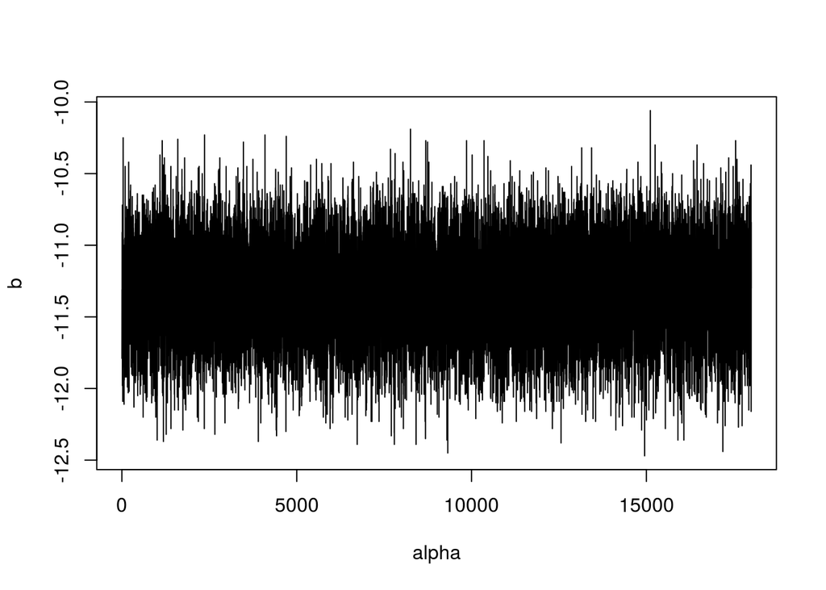

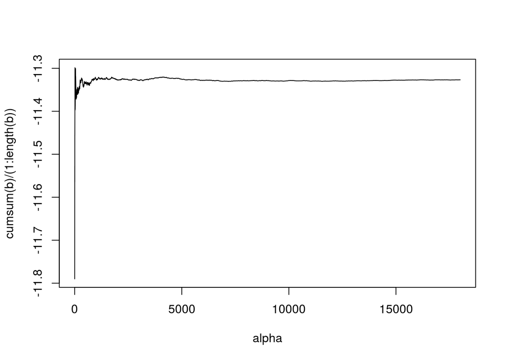

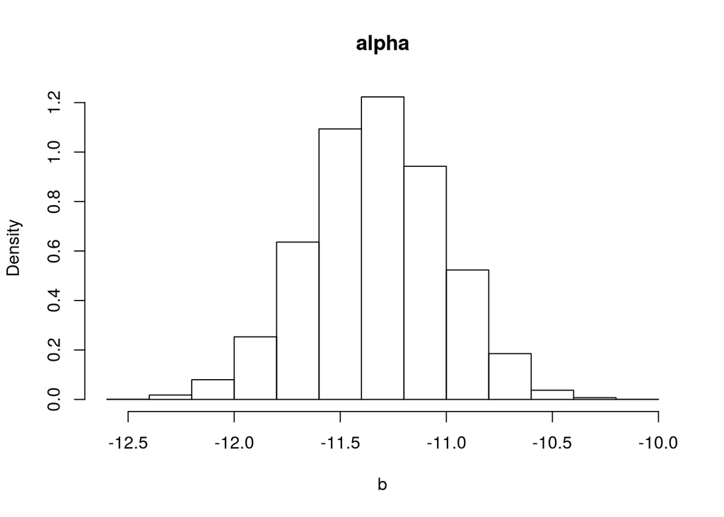

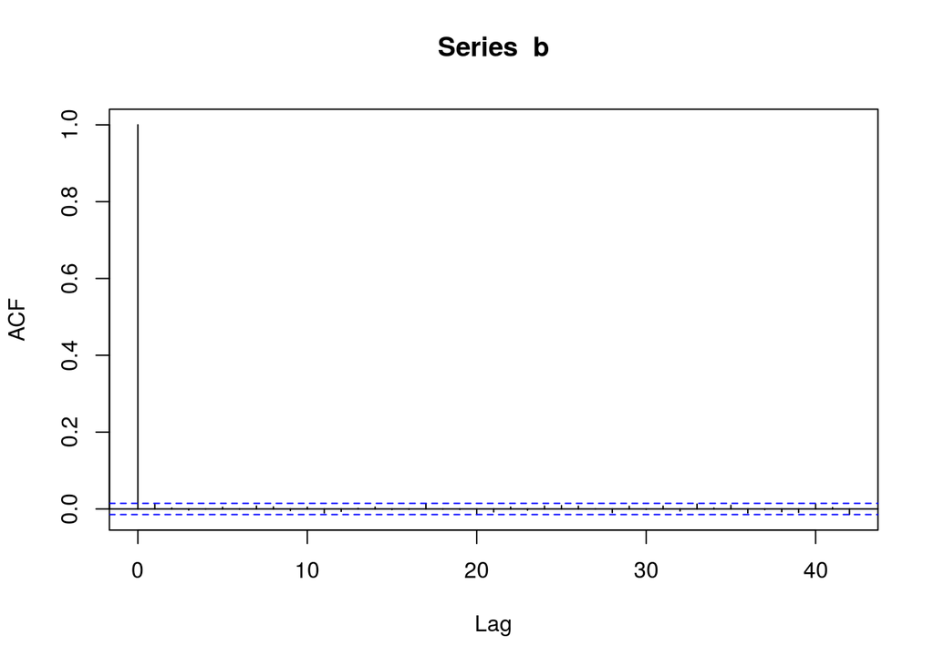

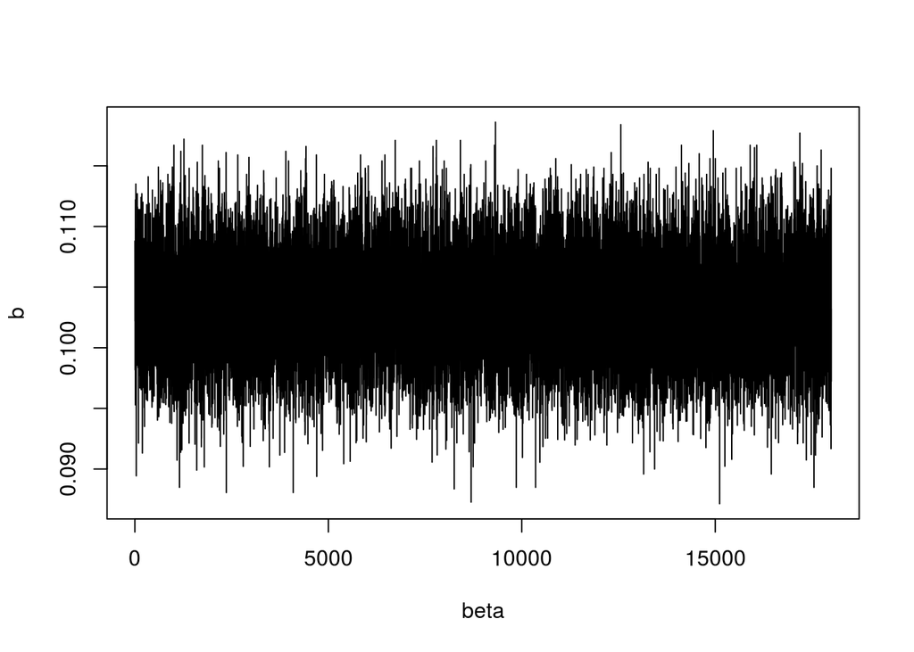

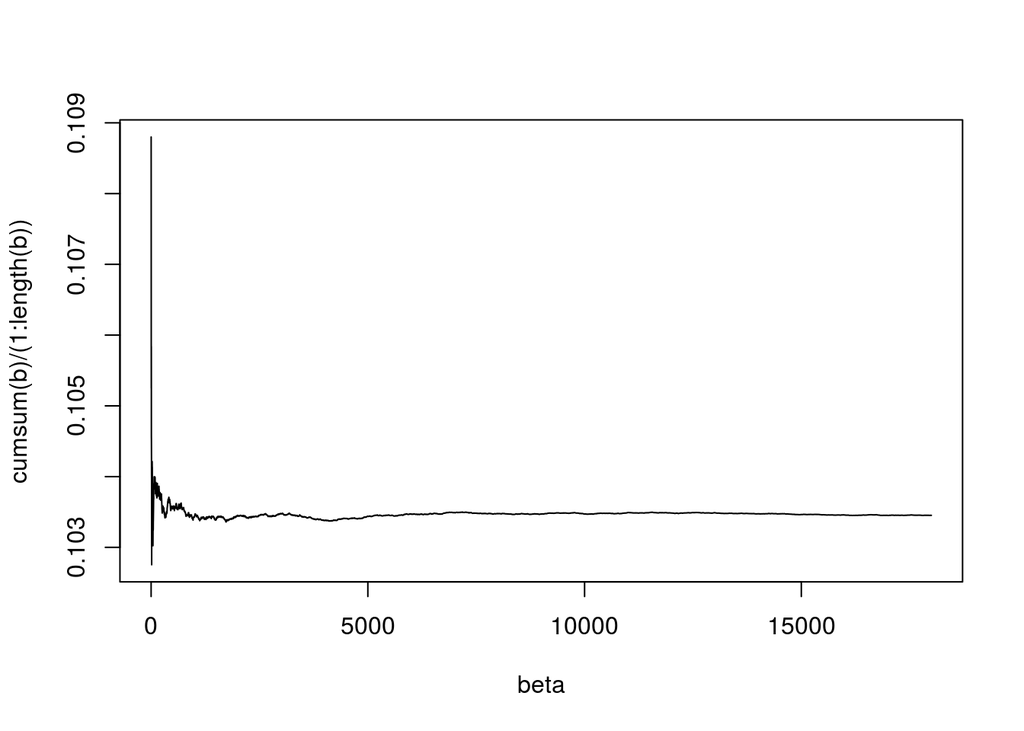

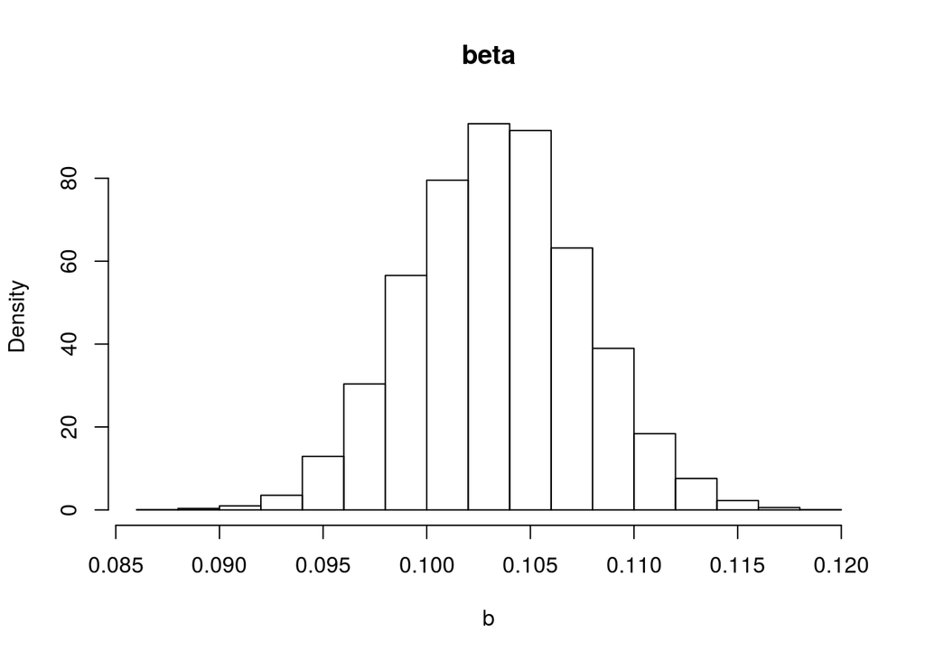

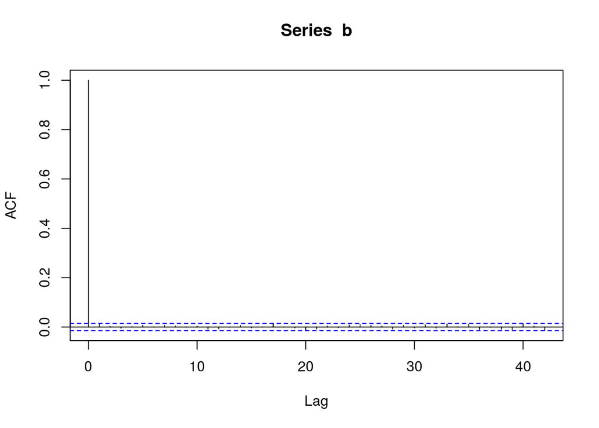

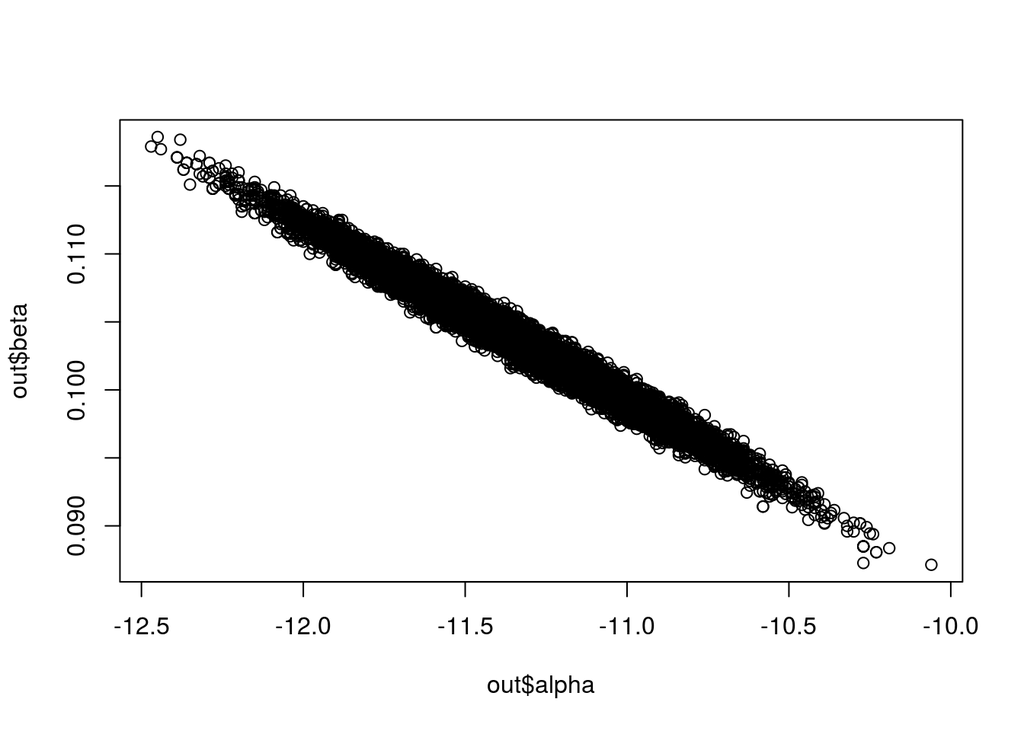

```r
out2h<-rex(ex2.simh)$sims.list
out2m<-rex(ex2.simm)$sims.list
out2.sumh<-rex(ex2.simh)$summary
out2.summ<-rex(ex2.simm)$summary

res(ex2.simh,out2h)
```

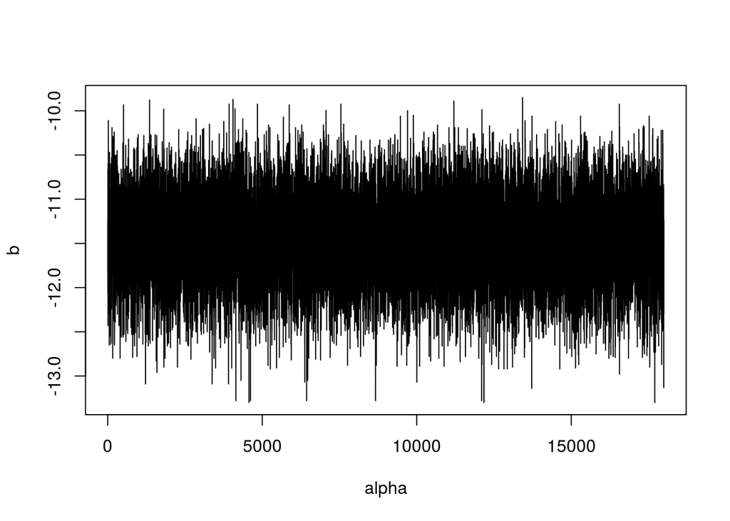

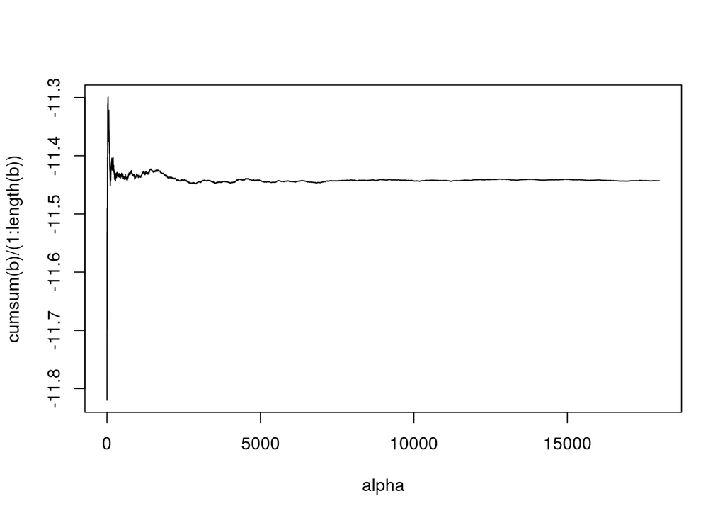

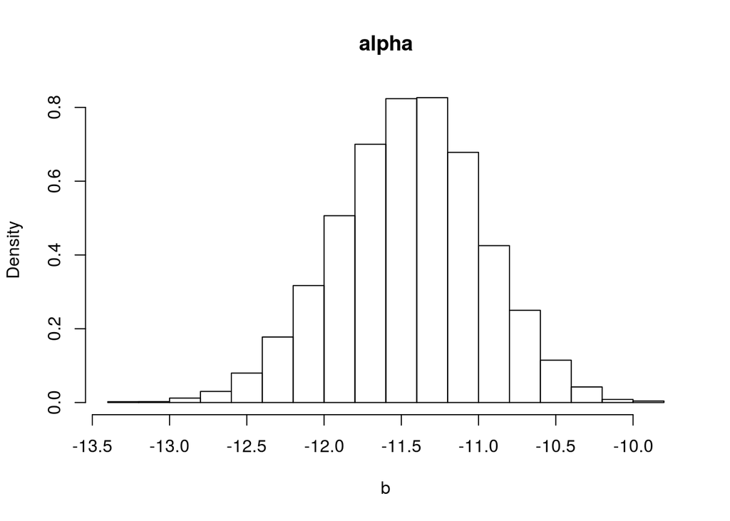

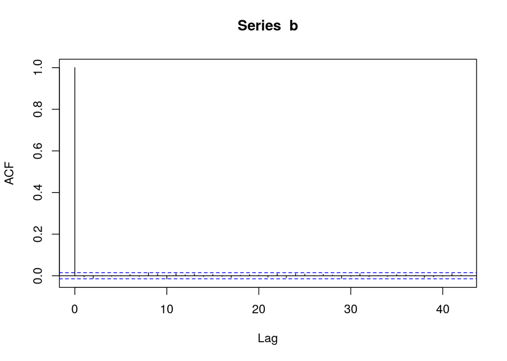

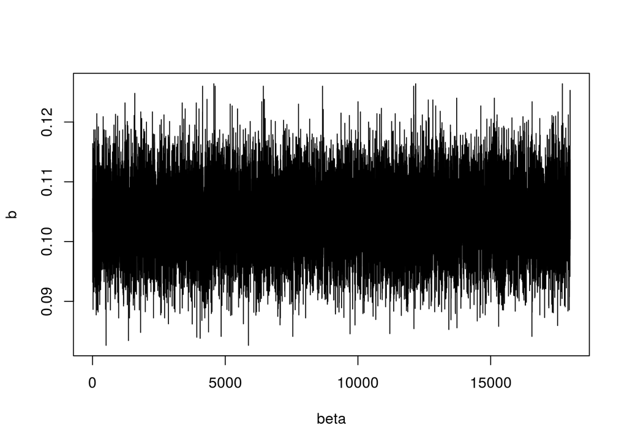

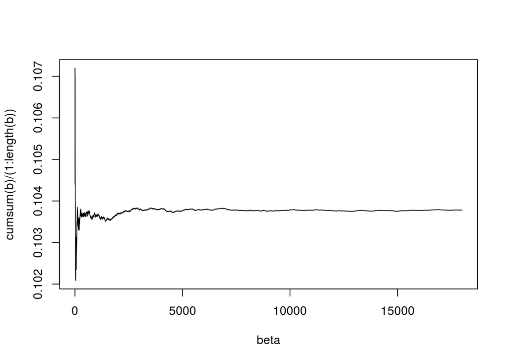

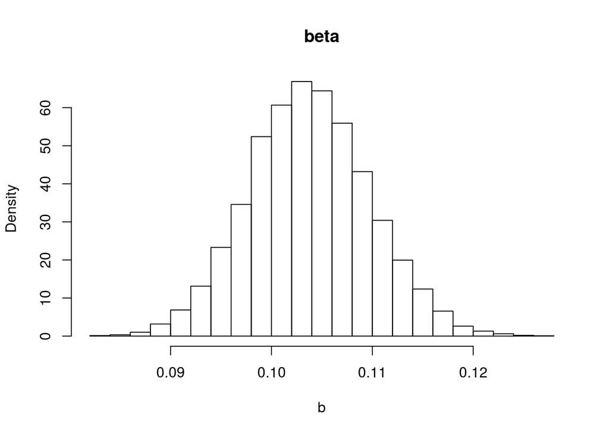

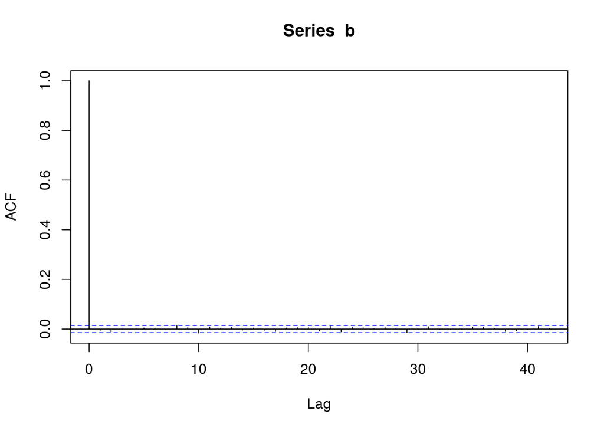

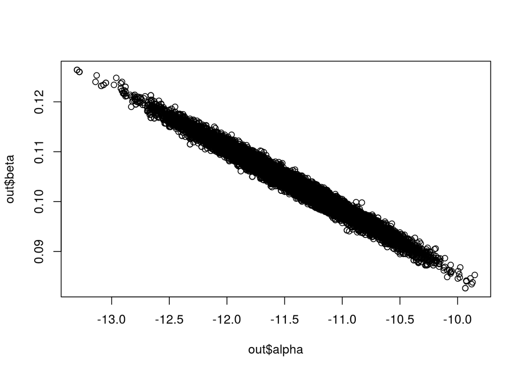

```r
res(ex2.simm,out2m)
```

ex2.sim<-ex2.simm out<-ex2.sim$sims.list

b<-out$alpha par(mfrow=c(1,1)) plot(b,type=“l”,xlab = “alpha”) plot(cumsum(b)/(1:length(b)),type=“l”,xlab = “alpha”) hist(b,freq=FALSE, main = “alpha”) acf(b)

b<-out$beta par(mfrow=c(1,1)) plot(b,type=“l”,xlab = “beta”) plot(cumsum(b)/(1:length(b)),type=“l”,xlab = “beta”) hist(b,freq=FALSE, main = “beta”) acf(b)

out.sum<-ex2.sim$summary

plot(out$alpha,out$beta)

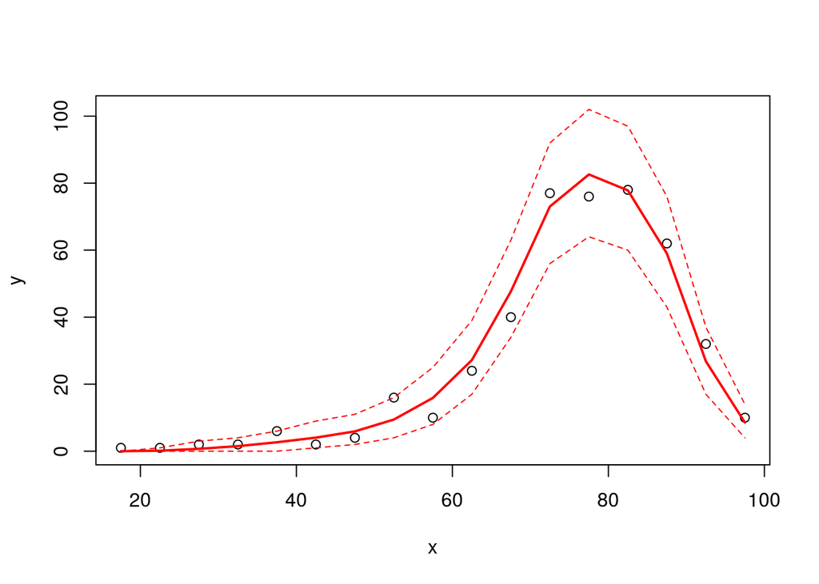

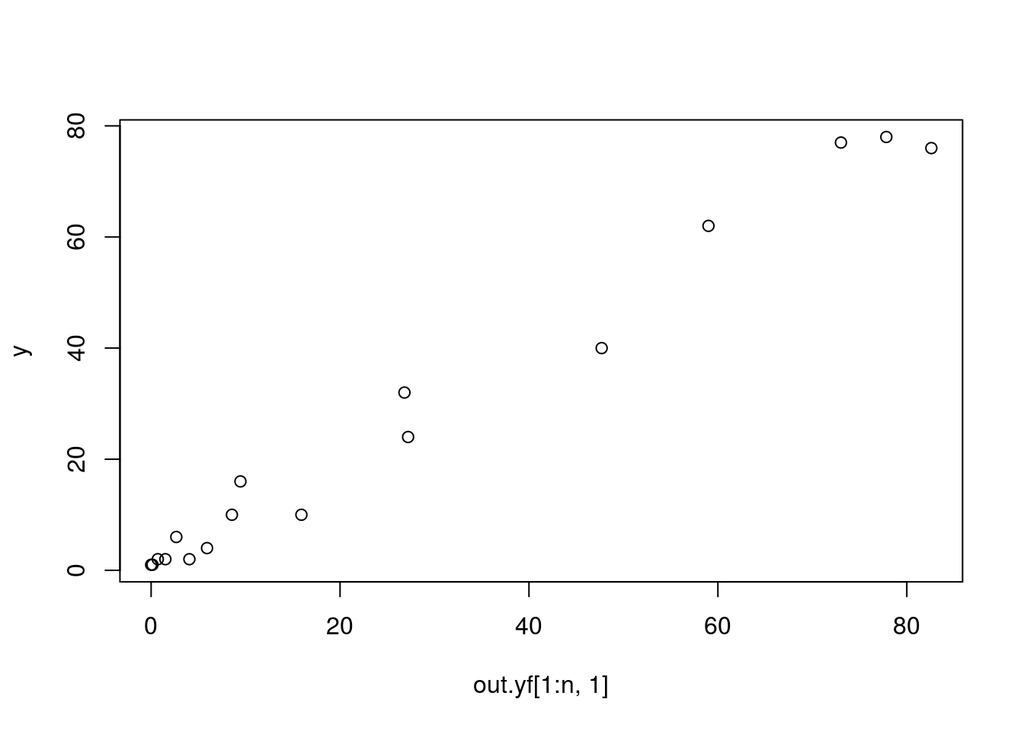

```r
adj(out2.sumh,mort$Muertes.H,"Df")
```

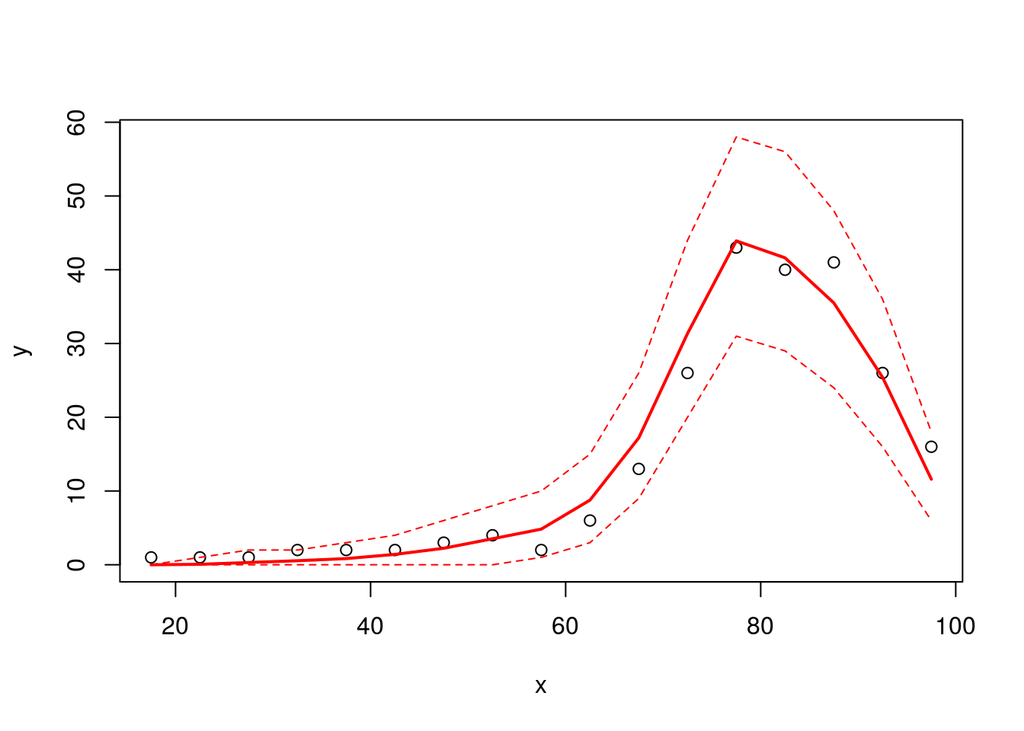

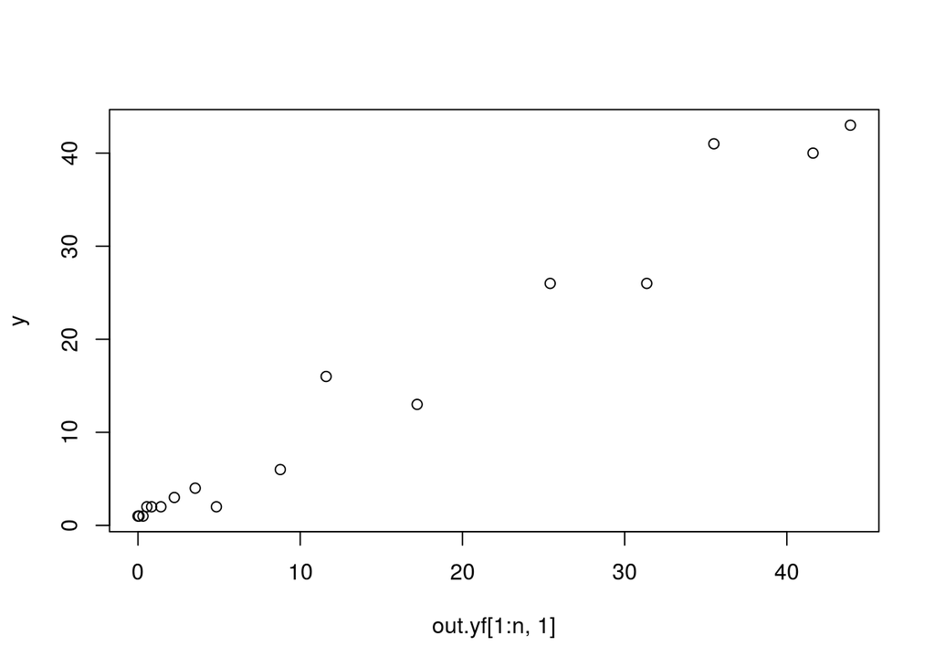

```r
adj(out2.summ,mort$Muertes.M,"Df")
```

y<-mort$Muertes.M

# Predictions

out.yf<-out.sum[grep(“Df”,rownames(out.sum)),] or<-order(x) ymin<-min(y,out.yf[,c(1,3,7)]) ymax<-max(y,out.yf[,c(1,3,7)]) par(mfrow=c(1,1)) plot(x,y,ylim=c(ymin,ymax)) lines(x[or],out.yf[or,1],lwd=2,col=2) lines(x[or],out.yf[or,3],lty=2,col=2) lines(x[or],out.yf[or,7],lty=2,col=2)

plot(out.yf[1:n,1],y,type =“p”)

```r
met(ex2.simh,out2.sumh)
```

```
## [1] 103.7
##                   mean           sd          2.5%          25%         50%
## alpha    -1.132676e+01 3.177986e-01 -1.195000e+01 -1.15400e+01 -1.1330e+01
## beta      1.034524e-01 4.168804e-03  9.539975e-02  1.00600e-01  1.0350e-01
## mu[1]     4.477423e-03 1.112304e-03  2.678000e-03  3.68800e-03  4.3330e-03
## mu[2]     1.469518e-01 3.340591e-02  9.189950e-02  1.23300e-01  1.4300e-01
## mu[3]     7.112602e-01 1.468357e-01  4.643975e-01  6.07775e-01  6.9570e-01
## mu[4]     1.511987e+00 2.809245e-01  1.031975e+00  1.31400e+00  1.4850e+00
## mu[5]     2.649651e+00 4.382799e-01  1.884000e+00  2.34300e+00  2.6110e+00
## mu[6]     4.050092e+00 5.886158e-01  3.011975e+00  3.63875e+00  4.0040e+00
## mu[7]     5.899780e+00 7.413350e-01  4.568000e+00  5.38200e+00  5.8500e+00
## mu[8]     9.422159e+00 1.003880e+00  7.585975e+00  8.72100e+00  9.3710e+00
## mu[9]     1.594611e+01 1.408359e+00  1.334000e+01  1.49600e+01  1.5885e+01
## mu[10]    2.723075e+01 1.949975e+00  2.360975e+01  2.58700e+01  2.7180e+01
## mu[11]    4.768621e+01 2.750732e+00  4.248000e+01  4.57700e+01  4.7640e+01
## mu[12]    7.300879e+01 3.564798e+00  6.625000e+01  7.05300e+01  7.2970e+01
## mu[13]    8.262914e+01 3.930108e+00  7.511000e+01  7.99400e+01  8.2560e+01
## mu[14]    7.785442e+01 4.175010e+00  7.002000e+01  7.49875e+01  7.7780e+01
## mu[15]    5.894441e+01 3.746928e+00  5.184000e+01  5.63700e+01  5.8840e+01
## mu[16]    2.683574e+01 1.975795e+00  2.311000e+01  2.54800e+01  2.6780e+01
## mu[17]    8.547585e+00 6.901080e-01  7.245000e+00  8.07200e+00  8.5280e+00
## Df[1]     4.333333e-03 6.568710e-02  0.000000e+00  0.00000e+00  0.0000e+00
## Df[2]     1.456667e-01 3.805118e-01  0.000000e+00  0.00000e+00  0.0000e+00
## Df[3]     7.091667e-01 8.517046e-01  0.000000e+00  0.00000e+00  1.0000e+00
## Df[4]     1.507611e+00 1.248121e+00  0.000000e+00  1.00000e+00  1.0000e+00
## Df[5]     2.666722e+00 1.687544e+00  0.000000e+00  1.00000e+00  2.0000e+00
## Df[6]     4.052333e+00 2.079276e+00  1.000000e+00  3.00000e+00  4.0000e+00
## Df[7]     5.919611e+00 2.537925e+00  2.000000e+00  4.00000e+00  6.0000e+00
## Df[8]     9.454778e+00 3.226140e+00  4.000000e+00  7.00000e+00  9.0000e+00
## Df[9]     1.591061e+01 4.230360e+00  8.000000e+00  1.30000e+01  1.6000e+01
## Df[10]    2.720489e+01 5.494333e+00  1.700000e+01  2.30000e+01  2.7000e+01
## Df[11]    4.769600e+01 7.361600e+00  3.400000e+01  4.30000e+01  4.7000e+01
## Df[12]    7.302844e+01 9.180310e+00  5.600000e+01  6.70000e+01  7.3000e+01
## Df[13]    8.259811e+01 9.764608e+00  6.400000e+01  7.60000e+01  8.2000e+01
## Df[14]    7.783178e+01 9.467653e+00  6.000000e+01  7.10000e+01  7.8000e+01
## Df[15]    5.900361e+01 8.220166e+00  4.300000e+01  5.30000e+01  5.9000e+01
## Df[16]    2.681939e+01 5.163884e+00  1.700000e+01  2.30000e+01  2.7000e+01
## Df[17]    8.555000e+00 2.656194e+00  4.000000e+00  7.00000e+00  8.0000e+00
## q[1]      7.588837e-05 1.885228e-05  4.538975e-05  6.25075e-05  7.3440e-05
## q[2]      1.266829e-04 2.879799e-05  7.922925e-05  1.06300e-04  1.2330e-04
```

[output cut: 56 more lines]

```
## q[4]       0.00039470  4.961000e-04 1.001115  8700
## q[5]       0.00065260  8.017050e-04 1.001114  8800
## q[6]       0.00108000  1.295000e-03 1.001111  8900
## q[7]       0.00178600  2.089000e-03 1.001108  9100
## q[8]       0.00295200  3.374000e-03 1.001101  9500
## q[9]       0.00487925  5.461000e-03 1.001089 10000
## q[10]      0.00806600  8.832025e-03 1.001066 12000
## q[11]      0.01334000  1.435000e-02 1.001024 18000
## q[12]      0.02205000  2.342000e-02 1.000970 18000
## q[13]      0.03641000  3.868000e-02 1.000943 18000
## q[14]      0.05991000  6.412025e-02 1.000968 18000
## q[15]      0.09731000  1.055000e-01 1.001006 18000
## q[16]      0.15460000  1.696000e-01 1.001034 17000
## q[17]      0.23690000  2.618000e-01 1.001052 14000
## deviance 102.50000000  1.070000e+02 1.001162  6800
```

```r
met(ex2.simm,out2.summ)
```

```
## [1] 94.82
##                   mean           sd          2.5%          25%         50%
## alpha    -1.144308e+01 4.739305e-01 -1.240000e+01 -1.17600e+01 -1.1430e+01
## beta      1.037830e-01 5.988303e-03  9.222000e-02  9.97100e-02  1.0370e-01
## mu[1]     1.058036e-03 3.957482e-04  4.678000e-04  7.73700e-04  9.9795e-04
## mu[2]     5.771281e-02 1.980422e-02  2.726000e-02  4.34775e-02  5.4950e-02
## mu[3]     3.034009e-01 9.487861e-02  1.537000e-01  2.35500e-01  2.9130e-01
## mu[4]     5.492979e-01 1.553030e-01  2.973950e-01  4.38900e-01  5.3160e-01
## mu[5]     8.381861e-01 2.122262e-01  4.843950e-01  6.87700e-01  8.1705e-01
## mu[6]     1.415499e+00 3.172789e-01  8.742925e-01  1.19100e+00  1.3890e+00
## mu[7]     2.261765e+00 4.424973e-01  1.489000e+00  1.95000e+00  2.2310e+00
## mu[8]     3.530262e+00 5.925300e-01  2.474000e+00  3.11600e+00  3.4975e+00
## mu[9]     4.831371e+00 6.813766e-01  3.590000e+00  4.35700e+00  4.7990e+00
## mu[10]    8.806981e+00 1.019721e+00  6.904975e+00  8.10000e+00  8.7720e+00
## mu[11]    1.722752e+01 1.607176e+00  1.421000e+01  1.61200e+01  1.7200e+01
## mu[12]    3.137026e+01 2.380118e+00  2.688000e+01  2.97600e+01  3.1340e+01
## mu[13]    4.395826e+01 2.956250e+00  3.841950e+01  4.19000e+01  4.3930e+01
## mu[14]    4.156875e+01 2.903936e+00  3.613975e+01  3.95600e+01  4.1510e+01
## mu[15]    3.549749e+01 2.872103e+00  3.013000e+01  3.35000e+01  3.5410e+01
## mu[16]    2.538149e+01 2.401771e+00  2.096000e+01  2.37300e+01  2.5280e+01
## mu[17]    1.160402e+01 1.227390e+00  9.362000e+00  1.07600e+01  1.1550e+01
## Df[1]     9.444444e-04 3.071815e-02  0.000000e+00  0.00000e+00  0.0000e+00
## Df[2]     6.261111e-02 2.510534e-01  0.000000e+00  0.00000e+00  0.0000e+00
## Df[3]     3.081111e-01 5.609283e-01  0.000000e+00  0.00000e+00  0.0000e+00
## Df[4]     5.471667e-01 7.554442e-01  0.000000e+00  0.00000e+00  0.0000e+00
## Df[5]     8.386667e-01 9.278514e-01  0.000000e+00  0.00000e+00  1.0000e+00
## Df[6]     1.410667e+00 1.215178e+00  0.000000e+00  0.00000e+00  1.0000e+00
## Df[7]     2.239167e+00 1.567550e+00  0.000000e+00  1.00000e+00  2.0000e+00
## Df[8]     3.526611e+00 1.972409e+00  0.000000e+00  2.00000e+00  3.0000e+00
## Df[9]     4.832222e+00 2.287922e+00  1.000000e+00  3.00000e+00  5.0000e+00
## Df[10]    8.772278e+00 3.124770e+00  3.000000e+00  7.00000e+00  9.0000e+00
## Df[11]    1.720700e+01 4.373454e+00  9.000000e+00  1.40000e+01  1.7000e+01
## Df[12]    3.136217e+01 6.007348e+00  2.000000e+01  2.70000e+01  3.1000e+01
## Df[13]    4.391622e+01 7.112853e+00  3.100000e+01  3.90000e+01  4.4000e+01
## Df[14]    4.161289e+01 6.939071e+00  2.900000e+01  3.70000e+01  4.1000e+01
## Df[15]    3.550022e+01 6.378961e+00  2.400000e+01  3.10000e+01  3.5000e+01
## Df[16]    2.540906e+01 5.251903e+00  1.600000e+01  2.20000e+01  2.5000e+01
## Df[17]    1.159650e+01 3.265825e+00  6.000000e+00  9.00000e+00  1.1000e+01
## q[1]      7.053576e-05 2.638337e-05  3.119000e-05  5.15800e-05  6.6535e-05
## q[2]      1.173027e-04 4.025271e-05  5.542000e-05  8.83675e-05  1.1170e-04
```

[output cut: 56 more lines]

```
## q[4]      3.78300e-04  5.356000e-04 1.000955 18000
## q[5]      6.23200e-04  8.496050e-04 1.000954 18000
## q[6]      1.02700e-03  1.350000e-03 1.000953 18000
## q[7]      1.69200e-03  2.145000e-03 1.000952 18000
## q[8]      2.78800e-03  3.411000e-03 1.000951 18000
## q[9]      4.59500e-03  5.438025e-03 1.000949 18000
## q[10]     7.57100e-03  8.691000e-03 1.000946 18000
## q[11]     1.24600e-02  1.396000e-02 1.000944 18000
## q[12]     2.05200e-02  2.249000e-02 1.000943 18000
## q[13]     3.38000e-02  3.676000e-02 1.000949 18000
## q[14]     5.56600e-02  6.079000e-02 1.000959 18000
## q[15]     9.09900e-02  1.006000e-01 1.000965 18000
## q[16]     1.45800e-01  1.641000e-01 1.000966 18000
## q[17]     2.25700e-01  2.573025e-01 1.000965 18000
## deviance  9.36000e+01  9.831025e+01 1.001187  6200
```

# DIC

out.dic<-ex2.sim$DIC #out.dic<-ej4.sim$BUGSoutput$DIC print(out.dic) print(out.sum)

```r
r2(mort$Muertes.H,out2.sumh,"Df")
```

```
## [1] 0.9814892
```

```r
r2(mort$Muertes.M,out2.summ,"Df")
```

```
## [1] 0.9694603
```

$R^2$

R2<-(cor(y,out.yf[1:n,1]))^2 print(R2)

```r
q2h<-out2.sumh[grep("q",rownames(out2.sumh)),c(1,3,7)]
q2m<-out2.summ[grep("q",rownames(out2.summ)),c(1,3,7)]
```

```r
(cor(ph,qh[,1]))^2
```

```
## [1] 0.9394585
```

```r
(cor(ph,q2h[,1]))^2
```

```
## [1] 0.9931193
```

```r
(cor(pm,qm[,1]))^2
```

```
## [1] 0.8762933
```

```r
(cor(pm,q2m[,1]))^2
```

```
## [1] 0.928072
```

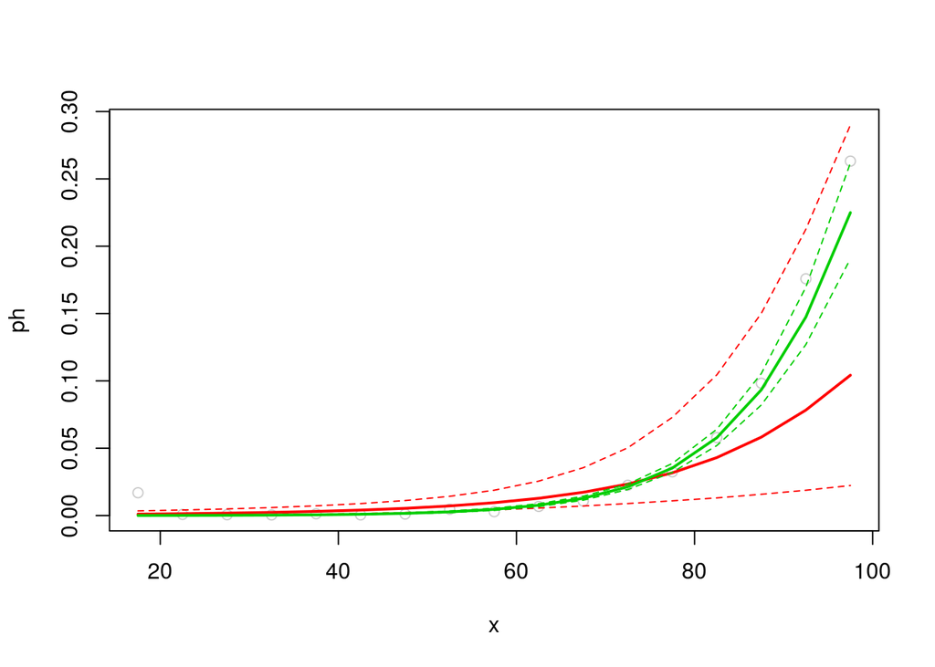

```r
#par(mfrow=c(1,1))
#plot(desastres,type="l",col="grey80",ylim=c(ymin,ymax))
#lines(desastres[,1],out.yf[,1],lwd=2,col=2)
#lines(desastres[,1],out.yf[,3],lty=2,col=2)
#lines(desastres[,1],out.yf[,7],lty=2,col=2)
#lines(desastres[,1],out.yf[,5],lwd=2,col=4)

ymin<-min(ph,qh[,c(1,2,3)])
ymax<-max(ph,qh[,c(1,2,3)])
or<-order(x)

par(mfrow=c(1,1))
plot(x,ph,type="p",col="grey80",ylim=c(ymin,ymax))
lines(x[or],qh[or,1],lwd=2,col=2)
lines(x[or],qh[or,2],lty=2,col=2)
lines(x[or],qh[or,3],lty=2,col=2)

#ymin<-min(ph,q2h[,c(1,2,3)])
#ymax<-max(ph,qh[,c(1,2,3)])
#or<-order(x)

#par(mfrow=c(1,1))
#plot(x,ph,type="p",col="grey80",ylim=c(ymin,ymax))
lines(x[or],q2h[or,1],lwd=2,col=3)
lines(x[or],q2h[or,2],lty=2,col=3)
lines(x[or],q2h[or,3],lty=2,col=3)
```

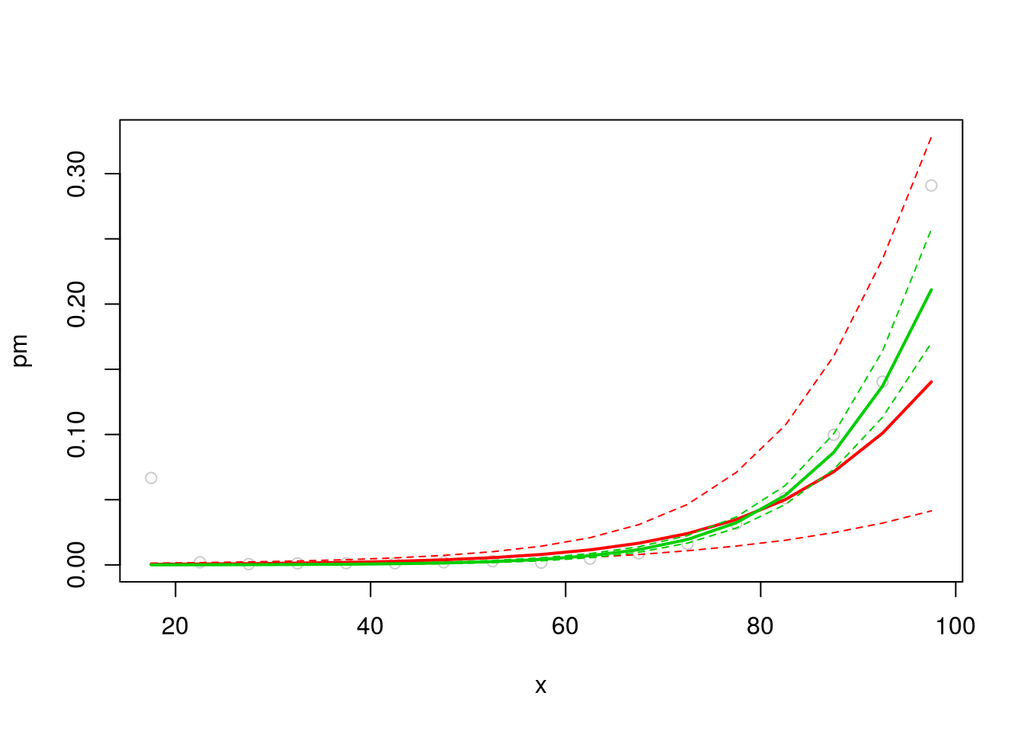

```r
#par(mfrow=c(1,1))
#plot(desastres,type="l",col="grey80",ylim=c(ymin,ymax))
#lines(desastres[,1],out.yf[,1],lwd=2,col=2)
#lines(desastres[,1],out.yf[,3],lty=2,col=2)
#lines(desastres[,1],out.yf[,7],lty=2,col=2)
#lines(desastres[,1],out.yf[,5],lwd=2,col=4)

ymin<-min(pm,qm[,c(1,2,3)])
ymax<-max(pm,qm[,c(1,2,3)])
or<-order(x)

par(mfrow=c(1,1))
plot(x,pm,type="p",col="grey80",ylim=c(ymin,ymax))
lines(x[or],qm[or,1],lwd=2,col=2)
lines(x[or],qm[or,2],lty=2,col=2)
lines(x[or],qm[or,3],lty=2,col=2)

#ymin<-min(ph,q2h[,c(1,2,3)])
#ymax<-max(ph,qh[,c(1,2,3)])
#or<-order(x)

#par(mfrow=c(1,1))
#plot(x,ph,type="p",col="grey80",ylim=c(ymin,ymax))
lines(x[or],q2m[or,1],lwd=2,col=3)
lines(x[or],q2m[or,2],lty=2,col=3)
lines(x[or],q2m[or,3],lty=2,col=3)
```

```r
alphah<-out2h$alpha
betah<-out2h$beta
```

```r
alpham<-out2m$alpha
betam<-out2m$beta
```

haciendo la prueba estadistica sobre las diferencias de $\alpha's$ y $\beta's$ podemos ver que los p-values son altos por tanto no se rechaza $H_{0}$ y sus medias son iguales.

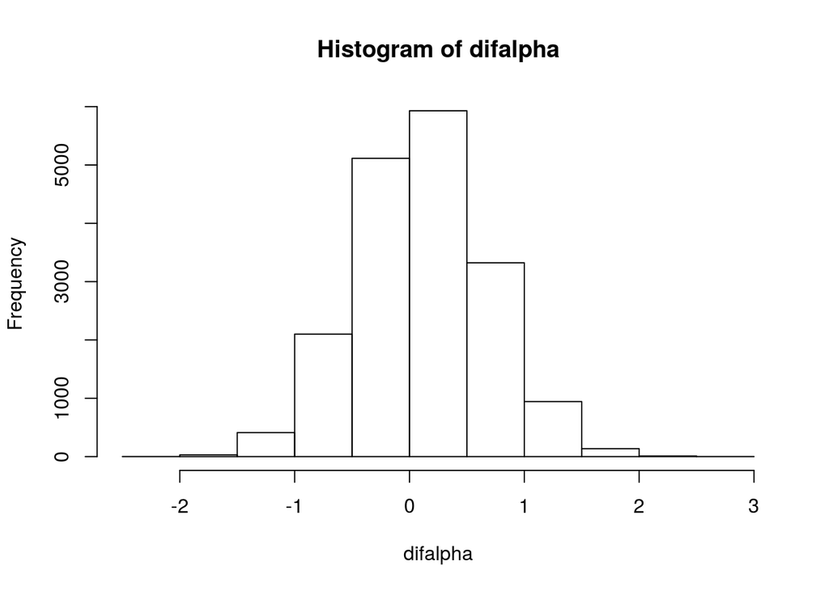

```r
difalpha<-alphah-alpham
hist(difalpha)
```

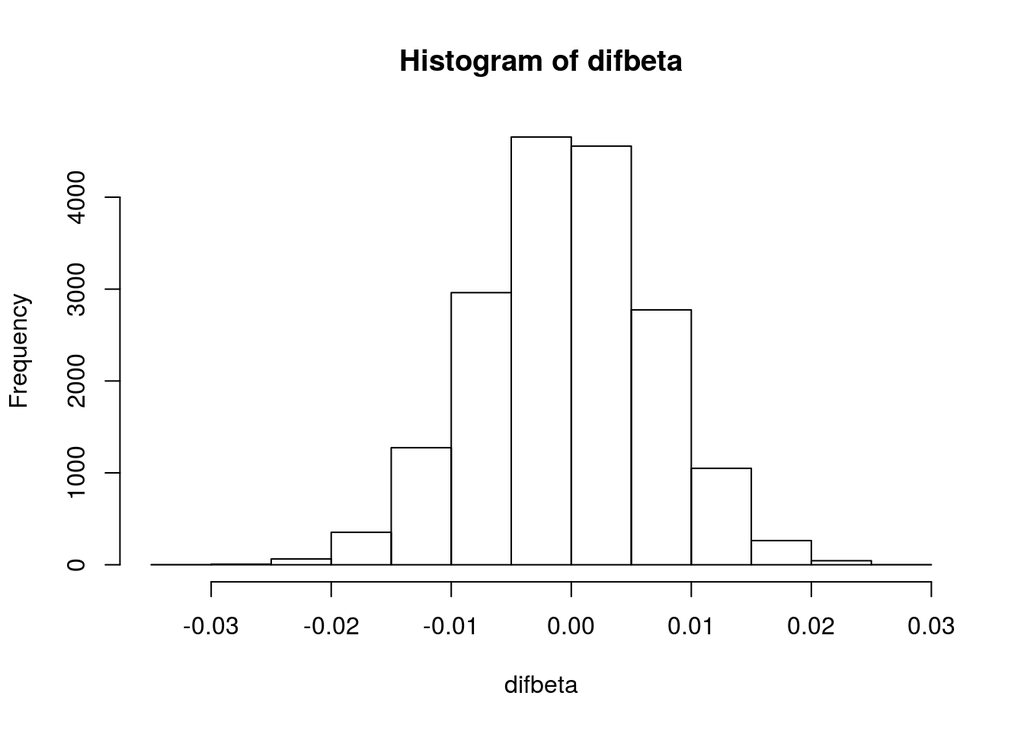

```r
difbeta<-betah-betam
hist(difbeta)
```

```r
prob(difalpha)
```

```
## [1] 0.4187778
```

```r
prob(difbeta)
```

```
## [1] 0.4826111
```

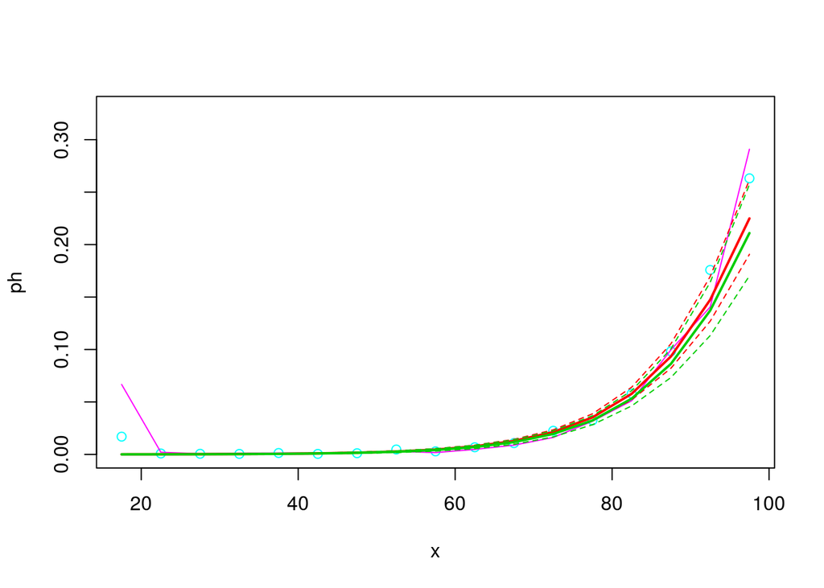

```r
ymin<-min(ph,qh[,c(1,2,3)],pm,qm[,c(1,2,3)])
ymax<-max(ph,qh[,c(1,2,3)],pm,qm[,c(1,2,3)])
or<-order(x)

par(mfrow=c(1,1))
plot(x,ph,type="p",col=5,ylim=c(ymin,ymax))
lines(x,pm,type="l",col=6,ylim=c(ymin,ymax))
lines(x[or],q2h[or,1],lwd=2,col=2)
lines(x[or],q2h[or,2],lty=2,col=2)
lines(x[or],q2h[or,3],lty=2,col=2)

lines(x[or],q2m[or,1],lwd=2,col=3)
lines(x[or],q2m[or,2],lty=2,col=3)
lines(x[or],q2m[or,3],lty=2,col=3)
```

Podemos ver quelos intervalos se traslapan, por ytanto no existe diferencia en la mortalidad de hombres y mujeres.

```r
exp(betah[1])
```

```
## [1] 1.114939
```

```r
exp(betam[1])
```

```
## [1] 1.113157
```

```r
exp(alphah[1])
```

```
## [1] 7.57998e-06
```

```r
exp(alpham[1])
```

```
## [1] 7.355958e-06
```